# Excess mortality

Data preparation

# COVID-19 data

Pulling data directly from [Johns Hopkins Coronavirus Resource Center](https://coronavirus.jhu.edu/about/how-to-use-our-data) [github repo](https://github.com/CSSEGISandData/COVID-19) (using [`csse_covid_19_daily_reports`](https://github.com/CSSEGISandData/COVID-19/tree/master/csse_covid_19_data/csse_covid_19_daily_reports) with appropriate time stamps).

Sources of data given for three analysed countries are:

- Spain - [RTVE](https://www.rtve.es/noticias/20200514/mapa-del-coronavirus-espana/2004681.shtml)
- Sweden - [The Swedish Public Health Agency](https://experience.arcgis.com/experience/09f821667ce64bf7be6f9f87457ed9aa)
- Switzerland
- [Federal Office Of Public Health](https://www.bag.admin.ch/bag/en/home/krankheiten/ausbrueche-epidemien-pandemien/aktuelle-ausbrueche-epidemien/novel-cov/situation-schweiz-und-international.html)
- [Open Government Data Reported By The Swiss Cantons](https://github.com/openZH/covid_19)

```r
covid_cases_deaths_jh_20 <-   read_csv("https://raw.githubusercontent.com/CSSEGISandData/COVID-19/master/csse_covid_19_data/csse_covid_19_daily_reports/12-31-2020.csv") %>%
  filter(Country_Region %in% c("Switzerland", "Sweden", "Spain")) %>%
  group_by(Country_Region) %>%
  summarise(Confirmed = sum(Confirmed, na.rm = TRUE),
            Deaths = sum(Deaths, na.rm = TRUE)) %>%
  ungroup() %>%
  mutate(Year = 2020)

covid_cases_deaths_jh <- bind_rows(

  covid_cases_deaths_jh_20,

  read_csv("https://raw.githubusercontent.com/CSSEGISandData/COVID-19/master/csse_covid_19_data/csse_covid_19_daily_reports/07-01-2021.csv") %>%
    filter(Country_Region %in% c("Switzerland", "Sweden", "Spain")) %>%
    group_by(Country_Region) %>%
    summarise(Confirmed = sum(Confirmed, na.rm = TRUE),
              Deaths = sum(Deaths, na.rm = TRUE)) %>%
    ungroup() %>%
    left_join(covid_cases_deaths_jh_20 %>%
                rename (Deaths_20 = Deaths,
                        Confirmed_20 = Confirmed)) %>%
    mutate(Deaths = Deaths - Deaths_20,
           Confirmed = Confirmed - Confirmed_20) %>%
    select(-ends_with("_20")) %>%
    mutate(Year = 2021)
) %>%
  rename(Country = Country_Region) %>%
  select(-Confirmed)

write_rds(covid_cases_deaths_jh, "data/covid_cases_deaths_jh.Rds")
```

# HMD - yearly data with age & sex structure

[The Human Mortality Database](https://www.mortality.org/) is the source of the data.

Available on yearly resolution only but for one year age bands & separate by sex.

The dataset has been last updated on `2021-11-10`.

In order to update newer data the [chunk option](https://yihui.org/knitr/options/) of the code snippet below has to be changed to `eval=TRUE` and a password to user account on mortality.org website provided (stored in plain text file `HMD.txt` in `secrets` directory of the project).

```r
p_load(HMDHFDplus)

# text file with password or modify password in calls below
password <- readr::read_file("secrets/HMD.txt")

# CH
# pop
hmd_ch_pop_raw <- readHMDweb(CNTRY = "CHE", item ="Population" ,
                             username = "r.panczak@gmail.com", password = password,
                             fixup = FALSE) %>%
  as_tibble()

write_rds(hmd_ch_pop_raw, "data-raw/mortality_org/hmd_ch_pop_raw.Rds")

# deaths
hmd_ch_deaths_raw <- readHMDweb(CNTRY = "CHE", item = "Deaths_1x1",
                                username = "r.panczak@gmail.com", password = password,
                                fixup = FALSE) %>%
  as_tibble()

write_rds(hmd_ch_deaths_raw, "data-raw/mortality_org/hmd_ch_deaths_raw.Rds")

# ES
# pop
# 1975 problem resolved in issue #45
hmd_es_pop_raw <- readHMDweb(CNTRY = "ESP", item ="Population" ,
                             username = "r.panczak@gmail.com", password = password,
                             fixup = FALSE) %>%
  as_tibble() %>%
  mutate(Year = ifelse(Year == "1975+", 1975, Year)) %>%
  filter(Year != "1975-") %>%
  mutate(Year = as.numeric(Year))

write_rds(hmd_es_pop_raw, "data-raw/mortality_org/hmd_es_pop_raw.Rds")

# deaths
hmd_es_deaths_raw <- readHMDweb(CNTRY = "ESP", item = "Deaths_1x1",
                                username = "r.panczak@gmail.com", password = password,
                                fixup = FALSE) %>%
  as_tibble()

write_rds(hmd_es_deaths_raw, "data-raw/mortality_org/hmd_es_deaths_raw.Rds")

# SE
# pop
hmd_se_pop_raw <- readHMDweb(CNTRY = "SWE", item ="Population" ,
                             username = "r.panczak@gmail.com", password = password,
                             fixup = FALSE) %>%
  as_tibble()

write_rds(hmd_se_pop_raw, "data-raw/mortality_org/hmd_se_pop_raw.Rds")

# deaths
hmd_se_deaths_raw <- readHMDweb(CNTRY = "SWE", item = "Deaths_1x1",
                                username = "r.panczak@gmail.com", password = password,
                                fixup = FALSE) %>%
  as_tibble()

write_rds(hmd_se_deaths_raw, "data-raw/mortality_org/hmd_se_deaths_raw.Rds")

p_unload(HMDHFDplus)
```

## Yearly deaths

Combining three countries into one dataset.

```r
hmd_deaths_age_sex <-
  bind_rows(
    read_rds("data-raw/mortality_org/hmd_es_deaths_raw.Rds") %>% mutate(Country = "Spain"),
    read_rds("data-raw/mortality_org/hmd_se_deaths_raw.Rds") %>% mutate(Country = "Sweden"),
    read_rds("data-raw/mortality_org/hmd_ch_deaths_raw.Rds") %>% mutate(Country = "Switzerland")
  ) %>%
  select(-Male, -Female) %>%
  mutate(Age = if_else(Age == "110+", "110", Age)) %>%
  mutate(Year = as.integer(Year),
         Age = as.integer(Age),
         Deaths = as.integer(round(Total))) %>%
  select(-Total) %>%
  relocate(Country)

write_rds(hmd_deaths_age_sex, "data/mortality_org/hmd_deaths_age_sex.Rds")
```

Note: Spain has *two years less* of data than other two countries:

```
# A tibble: 3 x 3
  Country       Min   Max
  <chr>       <int> <int>
1 Spain        1908  2018
2 Sweden       1751  2020
3 Switzerland  1876  2020
```

Yearly totals per country indicating different time frames of data.

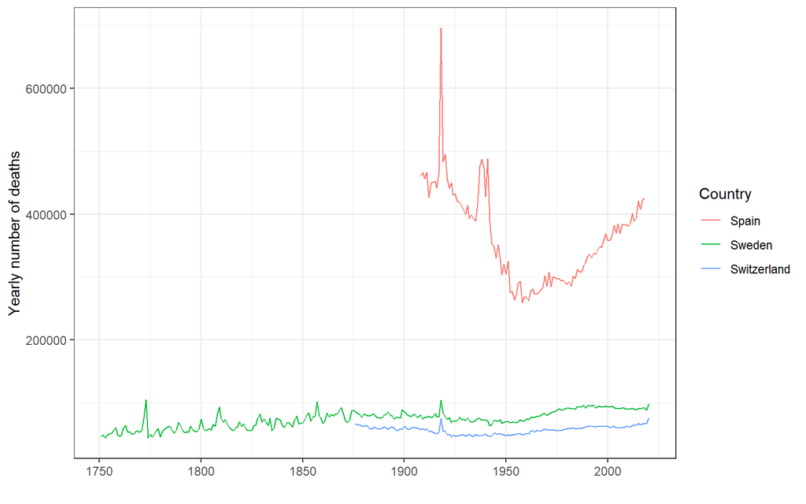

```r
hmd_deaths_year <- hmd_deaths_age_sex %>%
  group_by(Country, Year) %>%
  summarise(Deaths = as.integer(round(sum(Deaths)))) %>%
  ungroup()

write_rds(hmd_deaths_year, "data/mortality_org/hmd_deaths_year.Rds")
```

Example of age breakdown, showing demographic transition and first, crude indication of the effects of pandemics (and also - smaller coverage of ESP data!).

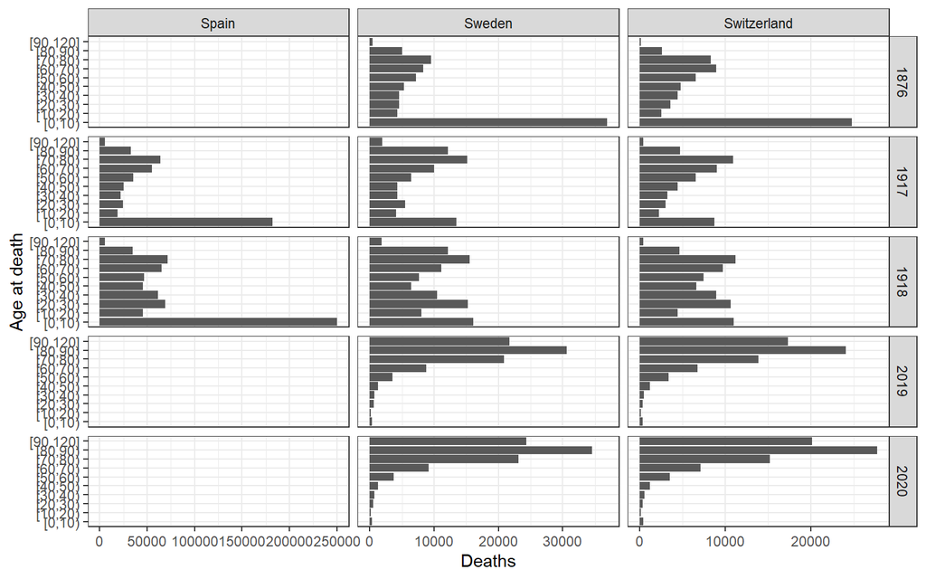

## Yearly population

Similarly, population data is available with 1y age bands by year.

Again, *Spain has less data*:

```
# A tibble: 3 x 3
  Country       Min   Max
  <chr>       <int> <int>
1 Spain        1908  2019
2 Sweden       1751  2021
3 Switzerland  1876  2021
```

Yearly totals

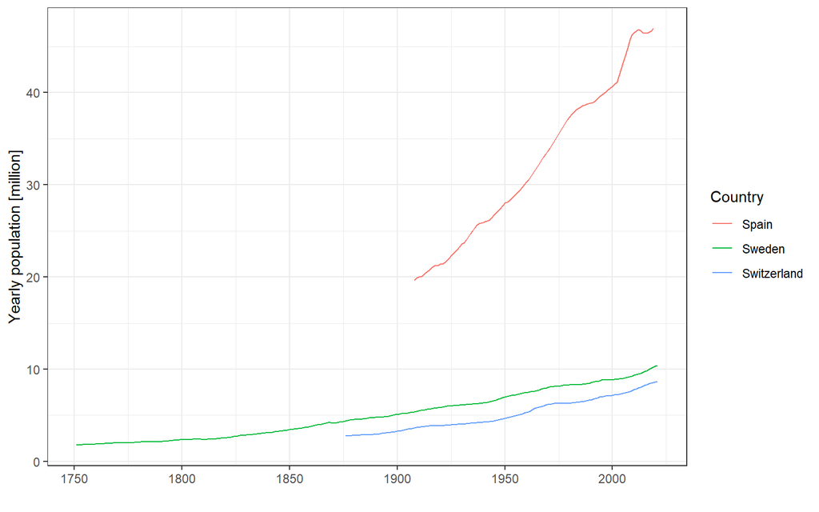

```r
hmd_pop_year <- hmd_pop_age_sex %>%
  group_by(Country, Year) %>%
  summarise(Population = as.integer(round(sum(Population)))) %>%
  ungroup()

write_rds(hmd_pop_year, "data/mortality_org/hmd_pop_year.Rds")
```

Again, age structure is available on yearly resolution. Example of three countries (starting in `1908` - at minimum year of coverage for all countries).

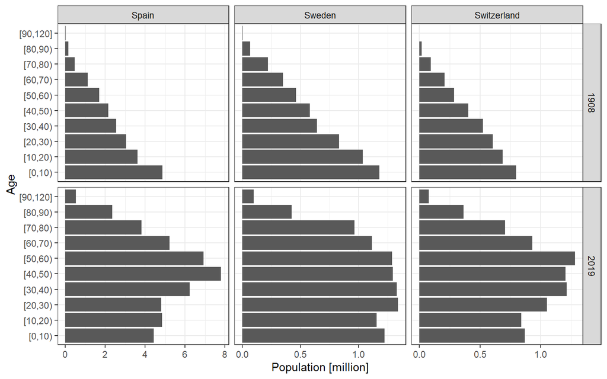

# Switzerland

## Monthly deaths until 2020

Historical data from [Todesfälle nach Monat und Sterblichkeit seit 1803](https://www.bfs.admin.ch/bfs/de/home/statistiken/kataloge-datenbanken/daten.assetdetail.18584915.html).

Using data **only since** `1877` when *monthly reporting starts*.

```r
ch_deaths_month <- read.px("data-raw/BfS/px-x-0102020206_111.px") %>%
  as_tibble() %>% remove_empty() %>% clean_names() %>%
  rename(Year = jahr,
         Deaths = value) %>%
  mutate(Year = as.numeric(as.character(Year))) %>%
  filter(Year >= 1877) %>%
  filter(str_detect(demografisches_merkmal_und_indikator, 'Todesfälle im')) %>%
  droplevels(.) %>%
  mutate(Month = rep(seq(1:12), times = nrow(.)/12) ) %>%
  select(-demografisches_merkmal_und_indikator) %>%
  mutate(Date = ymd(paste0(Year, "-", Month, "-01")),
         Year = as.integer(Year),
         Deaths = as.integer(Deaths)) %>%
  relocate(Year, Month, Date)
```

## Monthly 2021 deaths

BfS delivered custom data to supplement first six months of `2021`. Merged to dataset covering period until `2020`.

```r
ch_deaths_2021 <- read_csv("data-raw/BfS/Lieferung_Staub_2021_MonatsdatenJANbisJUN_Update04NOV21.csv", col_types = cols(TodJahr = col_integer(), TodMonat = col_integer(), Alter = col_integer(), COUNT = col_integer()), trim_ws = TRUE) %>%
  rename(Year = TodJahr, Month = TodMonat, Deaths = COUNT) %>%
  filter(Year == as.integer(2021)) %>%
  group_by(Year, Month) %>%
  summarise(Deaths = sum(Deaths)) %>%
  ungroup() %>%
  mutate(Date = ymd(paste0(Year, "-", Month, "-01")),
         Deaths = as.integer(round(Deaths))) %>%
  select(Year, Month, Date, Deaths)
```

## Monthly datasets combined

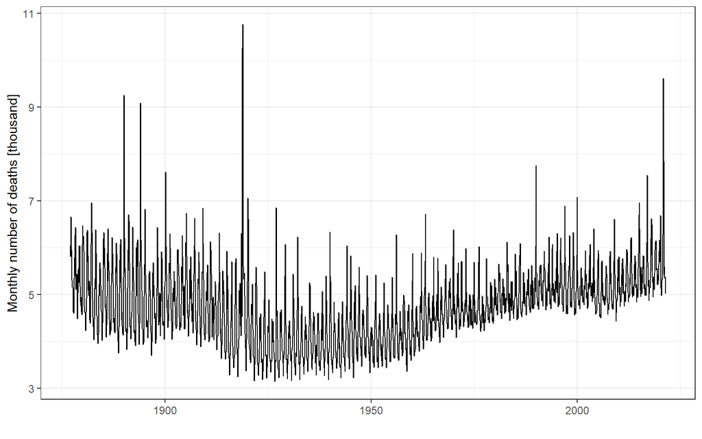

## Yearly 2021 deaths with age & sex structure

BfS delivered data to supplement missing six months of `2021`.

```r
ch_deaths_age_sex_2021 <- read_csv("data-raw/BfS/Lieferung_Staub_2021_MonatsdatenJANbisJUN_Update04NOV21.csv", col_types = cols(TodJahr = col_integer(), TodMonat = col_integer(), Alter = col_integer(), COUNT = col_integer()), trim_ws = TRUE) %>%
  rename(Year = TodJahr, Age = Alter, Sex = Geschlecht, Deaths = COUNT) %>%
  select(-TodMonat) %>%
  group_by(Year, Age) %>%
  summarise(Deaths = sum(Deaths)) %>%
  ungroup() %>%
  mutate(Country = "Switzerland",
         Deaths = as.integer(round(Deaths))) %>%
  relocate(Country)
```

# Spain

## Monthly deaths untill 2019

Data from INE: - data prior to 1940 was transcribed from PDFs available from INE  
- Vital Statistics: Deaths (Historical series 1941-1974) `1941-1974` [here](https://www.ine.es/jaxiT3/Tabla.htm?t=6563&L=1)  
- Vital Statistics: Deaths (Series since 1975)* since `1975` [here](https://www.ine.es/jaxiT3/Tabla.htm?t=6561&L=1)

```r
es_deaths_month <- read_xlsx("data-raw/INE/Spain.xlsx") %>%
  remove_empty(which = c("rows", "cols")) %>%
  clean_names() %>%
  rename(Year = jahr) %>%
  pivot_longer(!Year, names_to = "Month", values_to = "Deaths") %>%
  mutate(Month = as.integer(str_replace(Month, fixed("m"), "")),
         Year = as.integer(Year),
         Deaths = as.integer(round(Deaths)))  %>%
  mutate(Date = ymd(paste0(Year, "-", Month, "-01"))) %>%
  relocate(Year, Month, Date) %>%
  filter(Year != 2020)
```

## Monthly 2020 deaths

`2020` update is from *Vital Statistics. **Provisional** data: Year 2020* [here](https://www.ine.es/jaxi/Tabla.htm?path=/t20/e301/provi/l1/&file=02001.px&L=1)

```r
source("R/fn_get_death_data_spain.R")

es_2020 <- fn_get_death_data_spain("data-raw/INE/Spain_2020.xlsx") %>%
  gather(., Month, Deaths, January:December, factor_key = TRUE) %>%
  group_by(Month) %>%
  summarize(Deaths = sum(Deaths, na.rm = TRUE)) %>%
  ungroup() %>%
  mutate(Year = as.integer(2020),
         Deaths = as.integer(Deaths),
         Date = ymd(paste0(Year, Month, "-01")),
         Month = as.integer(Month)) %>%
  relocate(Year, Month, Date, Deaths)
```

## Monthly 2021 deaths

`2021` data is from *Estimate of number of weekly deaths during the Covid-19 outbreak* [here](https://www.ine.es/en/experimental/defunciones/experimental_defunciones.htm#tablas_resultados).

Note: data are in *weekly format* and **converted** with methods (and caveats!) described STMF chapter of weekly data doc.

```r
temp <- read_xlsx("data-raw/INE/Spain_2021_death_up.xlsx", skip = 9) %>%
  remove_empty(which = c("rows", "cols")) %>%
  clean_names() %>%
  rename(Week = x1) %>%
  filter(!is.na(from_0_to_4_years_old)) %>%
  mutate(Deaths = rowSums(.[-1])) %>%
  select(Week, Deaths)

es_2021 <- weekToMonth(rev(temp$Deaths), datStart = "31-12-2018") %>%
  as_tibble() %>%
  separate(yearMonth, c("Year", "Month"), convert = TRUE) %>%
  rename(Deaths = value) %>%
  mutate(Date = ymd(paste0(Year, "-", Month, "-01")),
         Deaths = as.integer(Deaths)) %>%
  relocate(Year, Month, Date) %>%
  filter(Year == 2021) %>%
  filter(Month <= 6)
```

## Monthly datasets combined

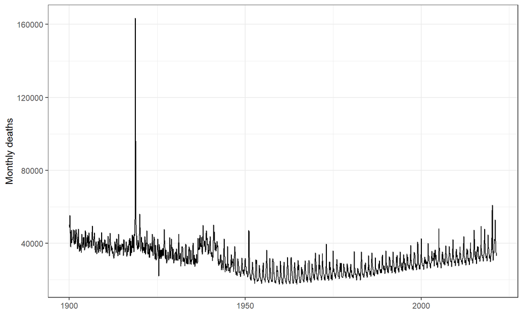

## Yearly 2019-2020 deaths with age structure

INE data to supplement missing 2019-20 years in HMD.

`2019` data available in *Vital Statistics: Deaths* [here](https://www.ine.es/jaxiT3/Tabla.htm?t=6547&L=1) and `2020` data available in*Vital Statistics. Provisional data: Year 2020* [here](https://www.ine.es/jaxi/Tabla.htm?path=/t20/e301/provi/l1/&file=02001.px&L=1).

```r
es_deaths_age_2019_2020 <- bind_rows(

  read_delim("data-raw/INE/Spain2019age.csv",
             delim = ";",
             locale = locale(grouping_mark = "."),
             trim_ws = TRUE) %>%
    mutate(Year = as.integer(2019)) %>%
    mutate(Age = word(Edad, 1),
           Age = str_replace(Age, fixed("Menores"), "0"),
           Age = as.integer(Age)
    ) %>%
    select(Year, Age, Total) %>%
    mutate(Deaths = as.integer(round(Total))) %>%
    select(-Total),

  fn_get_death_data_spain("data-raw/INE/Spain_2020.xlsx") %>%
    gather(., Month, Deaths, January:December, factor_key = TRUE) %>%
    group_by(Age) %>%
    dplyr::summarize(Deaths = sum(Deaths, na.rm = TRUE)) %>%
    mutate(Year = as.integer(2020),
           Deaths = as.integer(Deaths)) %>%
    select(Year, Age, Deaths)

) %>%
  mutate(Country = "Spain") %>% relocate(Country)
```

## Yearly 2021 deaths with age structure

INE data to supplement missing 6 months of `2021` in HMD available from *Weekly death estimates (EDeS) during the covid-19 outbreak* [here](https://www.ine.es/en/experimental/defunciones/experimental_defunciones.htm#tablas_resultados).

```r
temp <- read_xlsx("data-raw/INE/Spain_2021_death_up.xlsx", skip = 9) %>%
  remove_empty(which = c("rows", "cols")) %>%
  clean_names() %>%
  rename(Week = x1) %>%
  filter(!is.na(from_0_to_4_years_old))

es_deaths_age_2021 <- bind_rows(

  weekToMonth(rev(temp$from_0_to_4_years_old), datStart = "31-12-2018") %>%
    mutate(Age = 0) %>% as_tibble(),

  weekToMonth(rev(temp$from_5_to_9_years), datStart = "31-12-2018") %>%
    mutate(Age = 5) %>% as_tibble(),

  weekToMonth(rev(temp$from_10_to_14_years), datStart = "31-12-2018") %>%
    mutate(Age = 10) %>% as_tibble(),

  weekToMonth(rev(temp$from_15_to_19_years), datStart = "31-12-2018") %>%
    mutate(Age = 15) %>% as_tibble(),

  weekToMonth(rev(temp$from_20_to_24_years), datStart = "31-12-2018") %>%
    mutate(Age = 20) %>% as_tibble(),

  weekToMonth(rev(temp$from_25_to_29_years), datStart = "31-12-2018") %>%
    mutate(Age = 25) %>% as_tibble(),

  weekToMonth(rev(temp$from_30_to_34_years_old), datStart = "31-12-2018") %>%
    mutate(Age = 30) %>% as_tibble(),

  weekToMonth(rev(temp$from_35_to_39_years_old), datStart = "31-12-2018") %>%
    mutate(Age = 35) %>% as_tibble(),

  weekToMonth(rev(temp$from_40_to_44_years), datStart = "31-12-2018") %>%
    mutate(Age = 40) %>% as_tibble(),

  weekToMonth(rev(temp$from_45_to_49_years_old), datStart = "31-12-2018") %>%
    mutate(Age = 45) %>% as_tibble(),

  weekToMonth(rev(temp$from_50_to_54_years_old), datStart = "31-12-2018") %>%
    mutate(Age = 50) %>% as_tibble(),

  weekToMonth(rev(temp$from_55_to_59_years_old), datStart = "31-12-2018") %>%
    mutate(Age = 55) %>% as_tibble(),

  weekToMonth(rev(temp$from_60_to_64_years_old), datStart = "31-12-2018") %>%
    mutate(Age = 60) %>% as_tibble(),

  weekToMonth(rev(temp$from_65_to_69_years_old), datStart = "31-12-2018") %>%
    mutate(Age = 65) %>% as_tibble(),

  weekToMonth(rev(temp$from_70_to_74_years), datStart = "31-12-2018") %>%
    mutate(Age = 70) %>% as_tibble(),

  weekToMonth(rev(temp$from_75_to_79_years), datStart = "31-12-2018") %>%
    mutate(Age = 75) %>% as_tibble(),

  weekToMonth(rev(temp$from_80_to_84_years), datStart = "31-12-2018") %>%
    mutate(Age = 80) %>% as_tibble(),

  weekToMonth(rev(temp$from_85_to_89_years), datStart = "31-12-2018") %>%
    mutate(Age = 85) %>% as_tibble(),

  weekToMonth(rev(temp$x90_years_old_and_over), datStart = "31-12-2018") %>%
    mutate(Age = 90) %>% as_tibble()

) %>%
  as_tibble() %>%
  mutate(Country = "Spain") %>%
  separate(yearMonth, c("Year", "Month"), convert = TRUE) %>%
  rename(Deaths = value) %>%
  mutate(Deaths = as.integer(Deaths),
         Age = as.integer(Age)) %>%
  relocate(Country, Year, Month, Age) %>%
  filter(Year == 2021) %>%
  filter(Month <= 6) %>%
  group_by(Country, Year, Age) %>%
  summarise(Deaths = sum(Deaths)) %>%
  ungroup()

rm(temp)
```

# Sweden

## Monthly deaths untill 2020

```r
se_deaths_month <- read_csv("data-raw/SCB/000000NF_20210315-164930.csv",
                            skip = 2) %>%
  remove_empty(which = c("rows", "cols")) %>%
  clean_names() %>%
  rename(Month_txt = month) %>%
  filter(Month_txt != "Unknown") %>%
  select(-sex) %>%
  pivot_longer(!Month_txt, names_to = "Year", values_to = "Deaths") %>%
  group_by(Year, Month_txt) %>%
  summarise(Deaths = sum(Deaths)) %>%
  ungroup() %>%
  mutate(Year = as.integer(str_replace(Year, fixed("x"), "")),
         Month = match(Month_txt, month.name),
         Deaths = as.integer(round(Deaths))) %>%
  select(-Month_txt) %>%
  mutate(Date = ymd(paste0(Year, "-", Month, "-01"))) %>%
  relocate(Year, Month, Date) %>%
  arrange(Year, Month)
```

## Monthly 2021 deaths

[Preliminär statistik över döda (Excel)](https://www.scb.se/hitta-statistik/sverige-i-siffror/manniskorna-i-sverige/doda-i-sverige/) file is available from SCB. Data are available till October.

```r
# curl command doesn't work with this URL
# please download manually using link above!
download.file(url = "https://www.scb.se/hitta-statistik/statistik-efter-amne/befolkning/befolkningens-sammansattning/befolkningsstatistik/pong/tabell-och-diagram/preliminar-statistik-over-doda/",
              destfile = "data-raw/SCB/2021-08-23-preliminar_statistik_over_doda_inkl_eng.xlsx",
              method = "curl")
```

```r
se_deaths_month_2021 <- read_excel("data-raw/SCB/2021-11-01-preliminar_statistik_over_doda_inkl_eng.xlsx", sheet = "Tabell 10", skip = 10) %>%
  filter(Region == "Hela riket" & Period == "2021 antal") %>%
  select(Januari:Oktober) %>%
  pivot_longer(Januari:Oktober) %>%
  mutate(Year = as.integer(2021),
         Month = 1:10,
         Date = ymd(paste0(Year, "-", Month, "-01")),
         Deaths = as.integer(value)
  ) %>%
  select(-name, -value) %>%
  filter(Month <= 6)

se_deaths_month %<>%
  bind_rows(se_deaths_month_2021) %>%
  mutate(Country = "Sweden") %>% relocate(Country)
```

## Monthly deaths combined

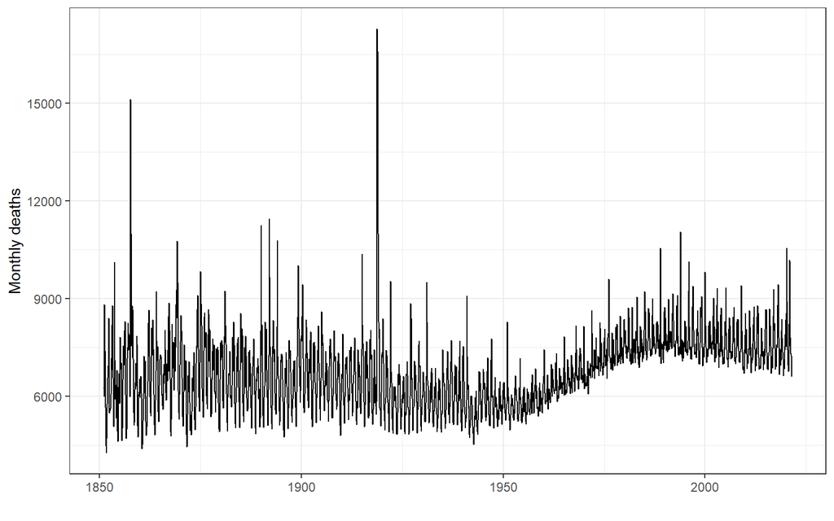

# Projected 2020-21 population numbers

Data used for projection come from HMD.

```r
hmd_pop_age_agg <- hmd_pop_age_sex %>%
  mutate(Age_cat = cut(Age, c(seq(0, 90, 10), 120),
                       include.lowest = TRUE, right = FALSE)) %>%
  group_by(Country, Year, Age_cat) %>%
  summarise(Population = sum(Population)) %>%
  ungroup()
```

As explained above, Spain has less data:

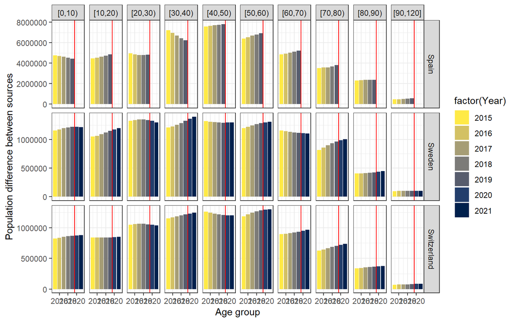

```r
hmd_pop_age_agg %>%
  # filter(Year >= 2010 & Year <= 2019) %>%
  filter(Year >= 2015) %>%
  ggplot(
    aes(x = Year, y = Population, fill = factor(Year))) +
  geom_col() +
  scale_y_continuous() +
  theme_bw() +
  scale_fill_viridis_d(option = "E", direction = -1) +
  xlab("Age group") + ylab("Population difference between sources") +
  facet_grid(vars(Country), vars(Age_cat), scales = "free_y") +
  geom_vline(xintercept = 2019.5, color = "red")
```

```r
# p_load(mgcv)
# p_load(splines)
# knots <- quantile(seq.int(2010, 2019), p = c(0.25, 0.5, 0.75))

pop_age_2020 <- hmd_pop_age_agg %>%
  filter(Year >= 2015 & Year <= 2019) %>%
  group_by(Country, Age_cat) %>%
  # do(broom::tidy(lm(population ~ year, data = .))) %>%
  # do(broom::augment(lm(population ~ year, data = .))) %>%
  # lm
  do(lm(Population ~ Year, data = .) %>%
       # polynomial
       # do(lm(Population ~ poly(Year, 2, raw = TRUE), data = .) %>%
       # spline
       # do(lm(Population ~ bs(Year, knots = knots), data = .) %>%
       # GAM
       # do(gam(Population ~ s(Year), data = .) %>%
       predict(., newdata = tibble(Year = c(2020, 2021))) %>%
       tibble(Year = c(2020, 2021),
              Population = .)
  ) %>%
  ungroup() %>%
  mutate(Population = as.integer(round(Population)),
         Year = as.integer(round(Year))) %>%
  arrange(Country, Year, Age_cat) %>%
  relocate(Country, Year, Age_cat, Population)
```

For comparison against `2020` & `2021` we use data from HMD (for SWE & CHE) and INE (for ESP). For the latter we use `Main series since 1971` from [here](https://www.ine.es/jaxiT3/Tabla.htm?t=31304). # HMD docs say that pop Spain 2013-2019 are from: *“1 Jan”* so using data from this time point for consistency.

```r
es_pop_age_new <-
  bind_rows(
    read_excel("data-raw/INE/Spain_Population_age-2019.xlsx",
               sheet=1,range="A8:H212") %>%
      slice(., -(1:2)) %>%
      select(1,8) %>%
      rename(Population=`Both sexes...8`) %>%
      filter(!is.na(Population)) %>%
      mutate(Age=0:(nrow(.)-1)) %>%
      select(Age, Population) %>%
      mutate(Year = as.integer(2020)),

    read_excel("data-raw/INE/Spain_Population_age-2019.xlsx",
               sheet=1,range="A8:B212") %>%
      slice(., -(1:2)) %>%
      rename(Population=`Both sexes`) %>%
      filter(!is.na(Population)) %>%
      mutate(Age=0:(nrow(.)-1)) %>%
      select(Age, Population) %>%
      mutate(Year = as.integer(2021))
  ) %>%
  mutate(Age_cat = cut(Age, c(seq(0, 90, 10), 120),
                       include.lowest = TRUE, right = FALSE
  )) %>%
  group_by(Year, Age_cat) %>%
  summarise(Population = sum(Population)) %>%
  ungroup() %>%
  mutate(Population = as.integer(Population),
         Country = "Spain") %>%
  relocate(Country, Year)
```

Absolute difference across countries and age groups in `2020/21`:

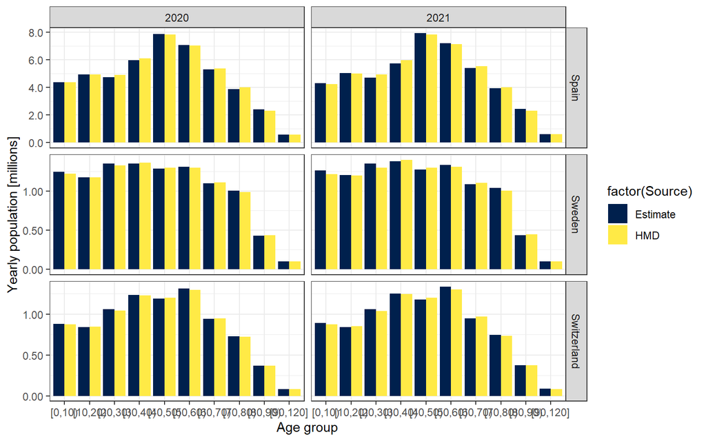

Relative differences in `2020/21`:

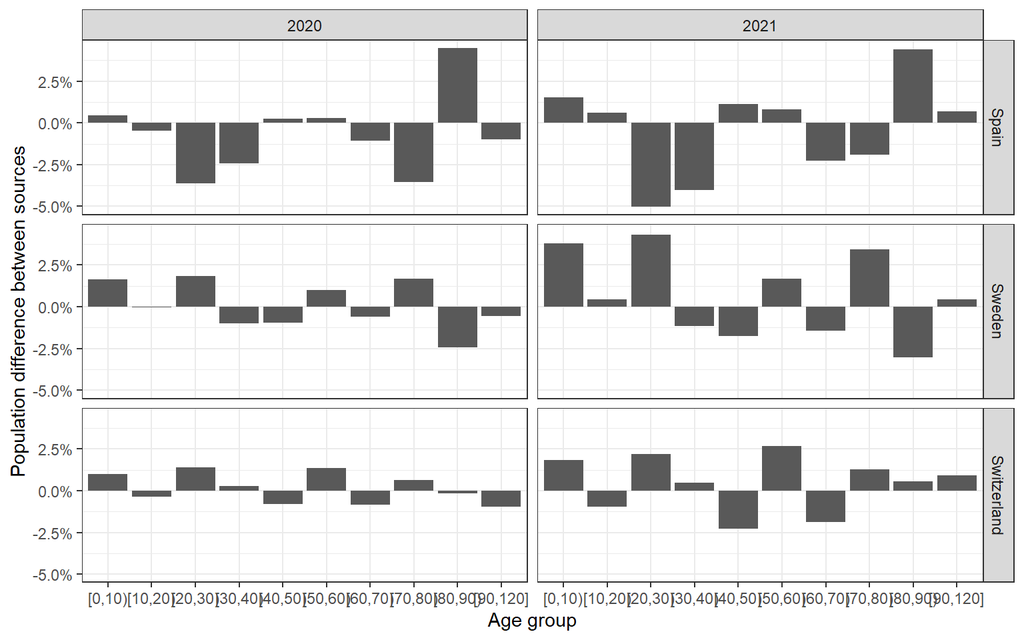

Fit & prediction `2020/21`:

```r
fn_age_plot <- function(country) {
  data %>%
    filter(Country == country) %>%
    ggplot(data = .,
           aes(x = Year, y = Population / 1000000,
               color = factor(Source))) +
    geom_point() +
    geom_smooth(data = . %>%
                  filter(Source == "HMD" & Year < 2020),
                colour = "grey40", size = 0.5,
                method = "lm",
                se = FALSE) +
    # geom_smooth(data = . %>%
    #               filter(Source == "HMD" & Year < 2020),
    #             method = "lm",
    #             # formula = y ~ poly(x, 2, raw = TRUE),
    #             formula = y ~ splines::bs(x, df = 3),
    #             # method = "gam",
    #             #   formula = y ~ s(x),
    #             se = FALSE) +
    scale_y_continuous(labels = comma) +
    theme_bw() +
    scale_colour_discrete(hue_pal()(2), name = "Source") +
    xlab("Year") + ylab("Population [millions]") +
    facet_wrap(vars(Age_cat), scales = "free_y")
}
```

## Spain

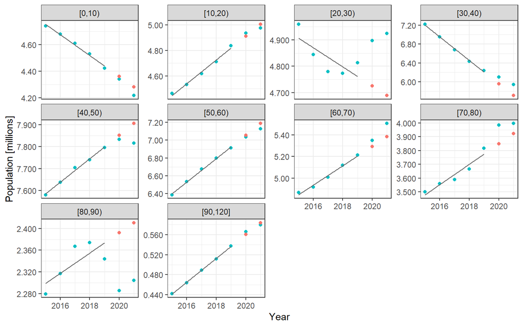

## Sweden

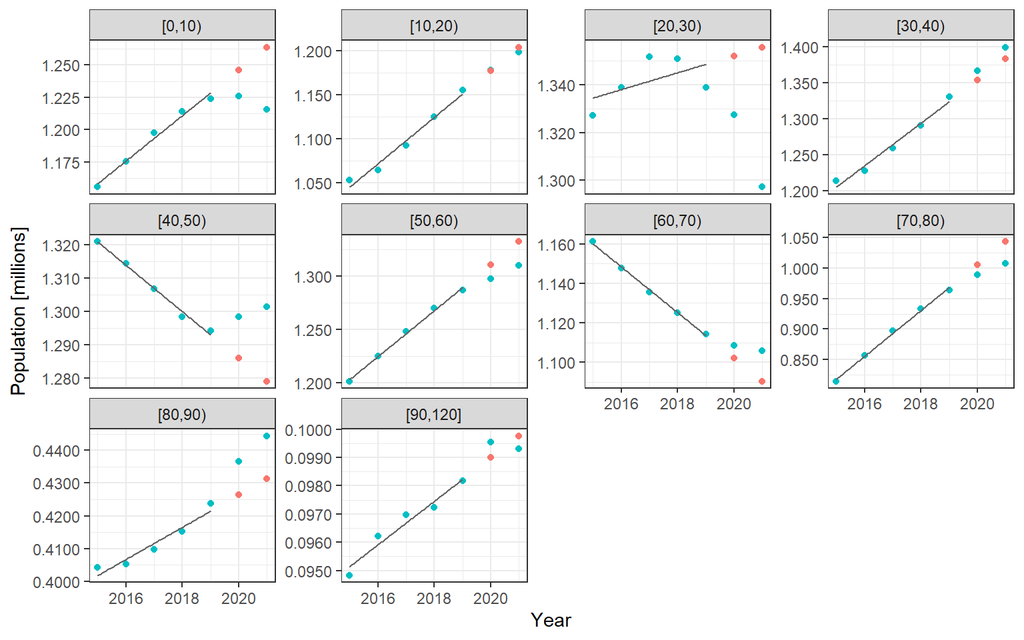

## Switzerland

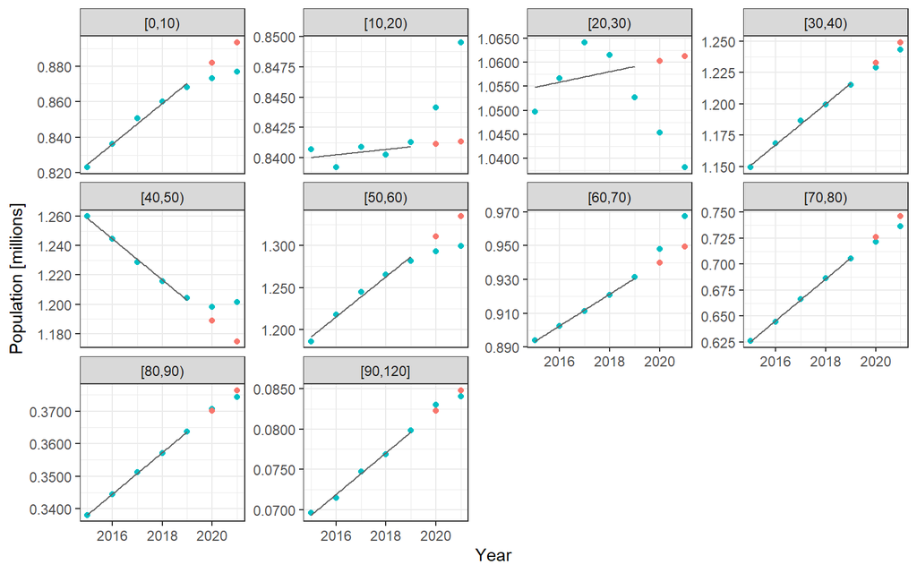

# Combined analysis datasets

## Population - predicted figures

Merging HMD until 2019 and predictions for 2020 & 2021.

```r
pop_age_sex_exp <- bind_rows(

  hmd_pop_age_agg %>%
    filter(Year < 2020),

  pop_age_2020
) %>%
  arrange(Country, Year, Age_cat) %>%
  rename(Population_exp = Population)

pop_yearly_exp <- pop_age_sex_exp %>%
  group_by(Country, Year) %>%
  summarise(Population_exp = sum(Population_exp)) %>%
  ungroup()
```

## Population - observed figures

Merging HMD until 2021 for CHE & SWE with INE data for ESP for 2020 & 2021.

```r
pop_age_sex_obs <- bind_rows(

  hmd_pop_age_agg,

  es_pop_age_new
) %>%
  arrange(Country, Year, Age_cat) %>%
  rename(Population_obs = Population)

pop_yearly_obs <- pop_age_sex_obs %>%
  group_by(Country, Year) %>%
  summarise(Population_obs = sum(Population_obs)) %>%
  ungroup()
```

## Monthly deaths with yearly pops

```r
deaths_monthly <- bind_rows(

  ### ESP - starting at 1908; see issue #81
  es_deaths_month %>%
    filter(Year >= 1908),

  # NAs for second half of year
  es_deaths_month %>%
    filter(Year == 2020 & Month > 6) %>%
    mutate(Year = as.integer(2021),
           Deaths = NA_integer_),

  ### SWE
  se_deaths_month,

  se_deaths_month %>%
    filter(Year == 2020 & Month > 6) %>%
    mutate(Year = as.integer(2021),
           Deaths = NA_integer_,
           Date = Date + years(1)),

  ch_deaths_month,

  ch_deaths_month %>%
    filter(Year == 2020 & Month > 6) %>%
    mutate(Year = as.integer(2021),
           Deaths = NA_integer_,
           Date = Date + years(1))

) %>%
  left_join(pop_yearly_obs) %>%
  left_join(pop_yearly_exp) %>%
  arrange(Country, Year, Month) %>%
  mutate(si_one = sin(2*pi*Month/12),
         si_two = sin(4*pi*Month/12),
         co_one = cos(2*pi*Month/12),
         co_two = cos(4*pi*Month/12))

write_rds(deaths_monthly, "data/deaths_monthly.Rds")
```

Data summary

| Name | deaths_monthly |
| --- | --- |
| Number of rows | 5160 |
| Number of columns | 11 |
| _______________________ |  |
| Column type frequency: |  |
| character | 1 |
| Date | 1 |
| numeric | 9 |
| ________________________ |  |
| Group variables | None |

**Variable type: character**

| skim_variable | n_missing | complete_rate | min | max | empty | n_unique | whitespace |
| --- | --- | --- | --- | --- | --- | --- | --- |
| Country | 0 | 1 | 5 | 11 | 0 | 3 | 0 |

**Variable type: Date**

| skim_variable | n_missing | complete_rate | min | max | median | n_unique |
| --- | --- | --- | --- | --- | --- | --- |
| Date | 0 | 1 | 1851-01-01 | 2021-12-01 | 1950-04-16 | 2052 |

**Variable type: numeric**

| skim_variable | n_missing | complete_rate | mean | sd | p0 | p25 | p50 | p75 | p100 | hist |
| --- | --- | --- | --- | --- | --- | --- | --- | --- | --- | --- |
| Year | 0 | 1 | 1947.94 | 44.46 | 1851.00 | 1914.00 | 1950.0 | 1986.00 | 2021.00 | ▃▆▇▇▇ |
| Month | 0 | 1 | 6.50 | 3.45 | 1.00 | 3.75 | 6.5 | 9.25 | 12.00 | ▇▅▅▅▇ |
| Deaths | 18 | 1 | 12381.92 | 11683.42 | 3138.00 | 5073.00 | 6548.5 | 19991.25 | 163422.00 | ▇▁▁▁▁ |
| Population_obs | 0 | 1 | 12962850.43 | 12692201.35 | 2766150.00 | 4645244.00 | 6915352.0 | 20598108.00 | 47394223.00 | ▇▁▁▁▁ |
| Population_exp | 0 | 1 | 12961746.35 | 12687827.68 | 2766150.00 | 4645244.00 | 6915352.0 | 20598108.00 | 47085087.00 | ▇▁▁▁▁ |
| si_one | 0 | 1 | 0.00 | 0.71 | -1.00 | -0.59 | 0.0 | 0.59 | 1.00 | ▇▅▅▅▇ |
| si_two | 0 | 1 | 0.00 | 0.71 | -0.87 | -0.87 | 0.0 | 0.87 | 0.87 | ▇▁▇▁▇ |
| co_one | 0 | 1 | 0.00 | 0.71 | -1.00 | -0.59 | 0.0 | 0.59 | 1.00 | ▇▅▅▅▇ |
| co_two | 0 | 1 | 0.00 | 0.71 | -1.00 | -0.50 | 0.0 | 0.50 | 1.00 | ▃▇▁▇▃ |

## Yearly deaths by sex and age group with pops

Spain age&sex distribution in HMD is [available from later](https://github.com/RPanczak/ISPM_excess-mortality/issues/81)!

```r
deaths_yearly_age_sex <- bind_rows(

  hmd_deaths_age_sex,

  # SWE
  # 2020 is already in HMD for SWE
  # 2021 is sadly missing for SWE

  #ESP
  es_deaths_age_2019_2020,
  es_deaths_age_2021,

  # CHE
  # 2020 is already in HMD for CHE
  ch_deaths_age_sex_2021

) %>%
  mutate(
    # Age_cat = cut(Age,
    # breaks = c(0, 1, 5, 20, 40, 60, 80, 112),
    # # labels = c("<1", "1-4", "5-19", "20-39", "40-59", "60-79","80+"),
    # right = FALSE),
    Age_cat = cut(Age,
                  breaks = c(seq(0, 90, 10), 120),
                  include.lowest = TRUE, right = FALSE)
  ) %>%
  group_by(Country, Year, Age_cat) %>%
  summarise(Deaths = sum(Deaths)) %>%
  ungroup() %>%
  left_join(pop_age_sex_obs) %>%
  left_join(pop_age_sex_exp)

# labels=c("0-9","10-19","20-29","30-39","40-49", "50-59","60-69","70-79","80-89","90+")

write_rds(deaths_yearly_age_sex, "data/deaths_yearly_age_sex.Rds")
```

Data summary

| Name | deaths_yearly_age_sex |
| --- | --- |
| Number of rows | 5300 |
| Number of columns | 6 |
| _______________________ |  |
| Column type frequency: |  |
| character | 1 |
| factor | 1 |
| numeric | 4 |
| ________________________ |  |
| Group variables | None |

**Variable type: character**

| skim_variable | n_missing | complete_rate | min | max | empty | n_unique | whitespace |
| --- | --- | --- | --- | --- | --- | --- | --- |
| Country | 0 | 1 | 5 | 11 | 0 | 3 | 0 |

**Variable type: factor**

| skim_variable | n_missing | complete_rate | ordered | n_unique | top_counts |
| --- | --- | --- | --- | --- | --- |
| Age_cat | 0 | 1 | FALSE | 10 | [0,: 530, [10: 530, [20: 530, [30: 530 |

**Variable type: numeric**

| skim_variable | n_missing | complete_rate | mean | sd | p0 | p25 | p50 | p75 | p100 | hist |
| --- | --- | --- | --- | --- | --- | --- | --- | --- | --- | --- |
| Year | 0 | 1 | 1919.85 | 71.23 | 1751 | 1879.00 | 1933 | 1977.0 | 2021 | ▃▂▅▇▇ |
| Deaths | 0 | 1 | 13170.75 | 22287.96 | 65 | 2694.75 | 5193 | 13933.5 | 250259 | ▇▁▁▁▁ |
| Population_obs | 0 | 1 | 1095818.15 | 1532831.43 | 378 | 211811.00 | 575000 | 1067678.0 | 8097288 | ▇▁▁▁▁ |
| Population_exp | 0 | 1 | 1095709.08 | 1532476.50 | 378 | 211811.00 | 575000 | 1067678.0 | 8097288 | ▇▁▁▁▁ |

To cite R in publications use:

R Core Team (2021). *R: A Language and Environment for Statistical Computing*. R Foundation for Statistical Computing, Vienna, Austria. https://www.R-project.org/.

To cite the `ggplot2` package in publications use:

Wickham H (2016). *ggplot2: Elegant Graphics for Data Analysis*. Springer-Verlag New York. ISBN 978-3-319-24277-4, https://ggplot2.tidyverse.org.